# Final assignment Travaglini Simone

Simone Travaglini

2023-01-05

First of all, i need to import my dataset. I will put it in an object called *trump_tweets* and open the packages i need

```r
## open packages and import the dataset

library(rio)
library(lubridate)
library(ggplot2)
library(dplyr)
library(tidyverse)
library(stringr)
options(scipen = 999)

setwd("/Users/trava/Downloads/")
trump_tweets <- import("trump_tweets.rds")
```

*TASK 1*

FIRST PLOT

```r
#transform the variable of days, months and years in a data format fith function as.date from lubridate
## data format yyyy-mm-dd

trump_tweets$date <- as.Date(paste(trump_tweets$year, trump_tweets$month, trump_tweets$day, sep = "-"))
```

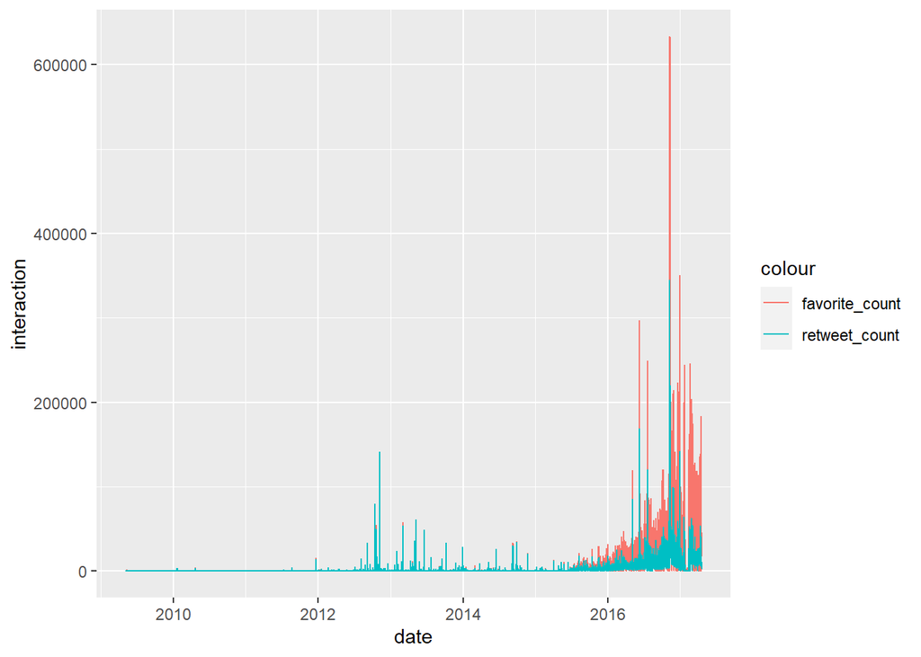

```r
ggplot(trump_tweets, aes(date)) +
  geom_line(aes(y = favorite_count, colour = "favorite_count")) +   geom_line(aes(y = retweet_count, colour = "retweet_count")) +
  labs(y= "interaction", x = "date")
```

the first graph shows the interactions there have been with trump’s tweets from other users. until around 2013 there were not many interactions, but things improved after 2015, i.e. since he ran in the primaries for the republican party. i think that this plot is interesting because show us the increase of the interaction among trump and his followers. it means that during this period trump became very popular

SECOND PLOT

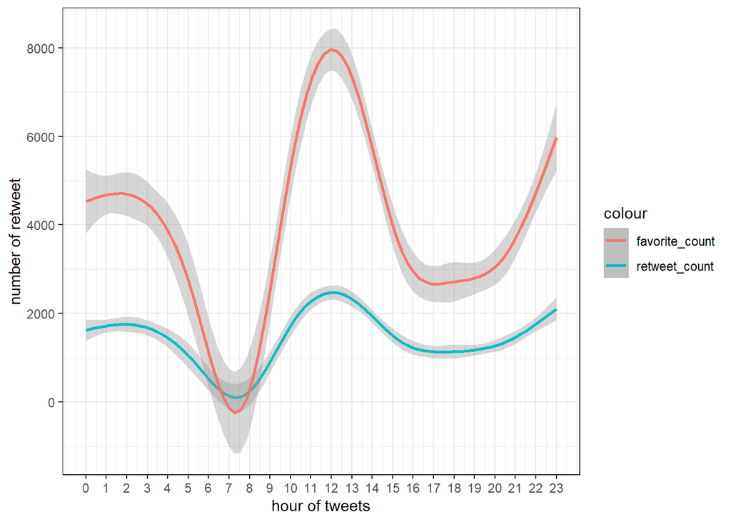

```r
ggplot(trump_tweets, aes(x = hour)) +
  geom_smooth(aes(y=retweet_count, col="retweet_count")) +
  geom_smooth(aes(y=favorite_count, col="favorite_count"))+
  ylab("number of retweet") +
  xlab("hour of tweets") +
  scale_x_continuous(breaks = seq(0, 23, by = 1)) +
  theme_bw()
```

the second plot show us the number of reetweets and favorites interaction per hour: as the plot can shows, the two lines have similar trends: most interactions occurred around midday, while the lowest peak occurred early in the morning (around 7 a.m.). this graph is important because social media analysts have shown that in addition to the content posted on social networks, the time of day in which to post is also important: there are time slots in which there is a greater chance that content will be seen and interacted with .

THIRD PLOT

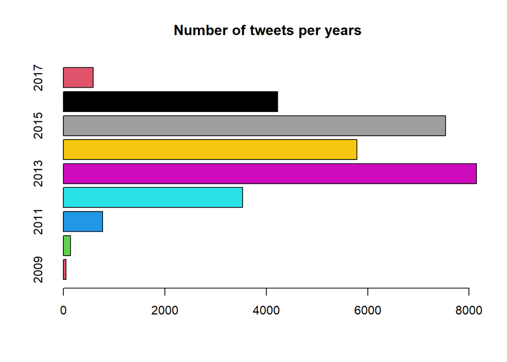

```r
##create a character string for year variable, in order to make a graph
years1 <- c(trump_tweets$year)

barplot(table(years1),
        main = "Number of tweets per years",
        col = (2:9),
        horiz = T
        )
```

*TASK2*

First, i need to recode the source’ variables:

```r
##recode and create the variable source2 with %>% and str_detect function from stringr

trump_tweets <- trump_tweets %>%
  mutate(
    source2 = case_when(
      str_detect(source, "Android") ~ "Android",
      str_detect(source, "iPhone") ~ "Iphone",
      TRUE ~ "Other"
    )
  )
```

```r
table(trump_tweets$source)
```

```
##
##                 Facebook                Instagram             Media Studio
##                      105                      133                        2
##          Mobile Web (M5) Neatly For BlackBerry 10                Periscope
##                       56                        5                        7
##                TweetDeck               Twitlonger          TwitLonger Beta
##                      483                       23                      405
##              Twitter Ads      Twitter for Android   Twitter for BlackBerry
##                       69                    14545                       97
##         Twitter for iPad       Twitter for iPhone     Twitter for Websites
##                       22                     2671                        1
##  Twitter Mirror for iPad            Twitter QandA       Twitter Web Client
##                        1                       10                    12135
##      Vine - Make a Scene
##                       10
```

here above we can see the original source for the variable. below instead the recoded variable, called “source2”

```r
table(trump_tweets$source2)
```

```
##
## Android  Iphone   Other
##   14545    2671   13564
```

*Negative expression plot*

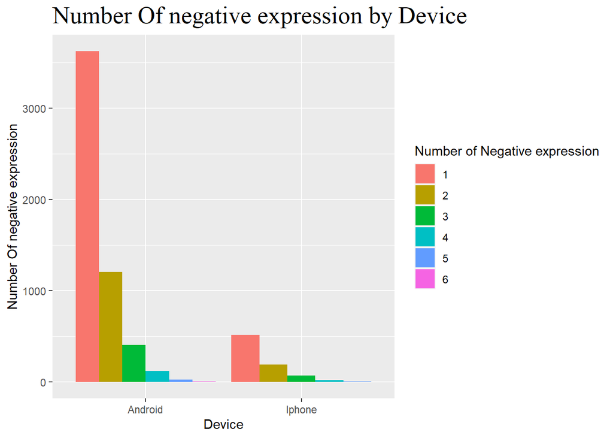

```r
trump_tweets %>%
  filter(source2=="Android"|
           source2=="Iphone"|
           source2=="Others") %>%
  filter(negative>0) %>%
  ggplot(aes(factor(source2), fill = factor(negative))) +
  geom_bar(stat = "count", position = "dodge")+
  scale_x_discrete(labels= c("Android", "Iphone"))+
  ggtitle("Number Of negative expression by Device")+
  xlab("Device") +
  ylab("Number Of negative expression") +
  labs(fill = "Number of Negative expression")+
  theme(plot.title = element_text(family = "serif", size = (20)))
```

*Positive expression plot*

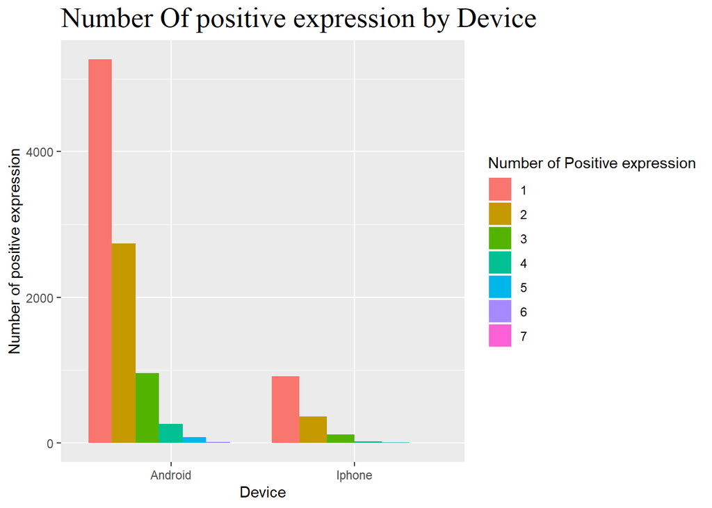

```r
trump_tweets %>%
  filter(source2=="Android"|
           source2=="Iphone"|
           source2=="Others") %>%
  filter(positive>0) %>%
  ggplot(aes(factor(source2), fill = factor(positive))) +
  geom_bar(stat = "count", position = "dodge")+
  scale_x_discrete(labels= c("Android", "Iphone"))+
  ggtitle("Number Of positive expression by Device")+
  xlab("Device") +
  ylab("Number of positive expression") +
  labs(fill = "Number of Positive expression")+
  theme(plot.title = element_text(family = "serif", size = (20)))
```

the two graphs above show, in order, the use of negative and positive expressions divided by device (android=trump, iphone=staff) from these two graphs you can see that the trends are very similar. the only thing to note is the fact that trump uses many more expressions (both positive and negative) unlike his staff, who tend to write more neutral tweets

*Emotion plot*

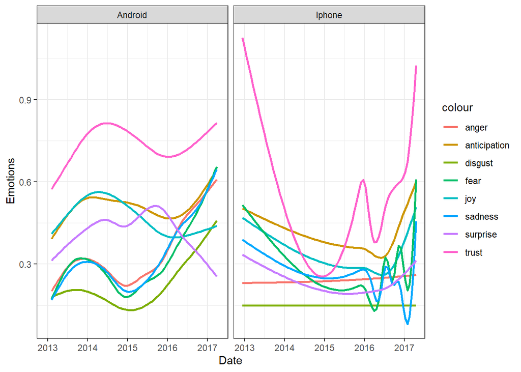

```r
##before the plot i set a filter for source2
trump_tweets %>%
  filter(source2=="Android"|
           source2=="Iphone") %>%
  ggplot(aes(x=date))+
  geom_smooth(aes(y=anger, colour= "anger"), se=FALSE)+
  geom_smooth(aes(y=anticipation, colour= "anticipation"), se=FALSE)+
  geom_smooth(aes(y=disgust, colour= "disgust"), se=FALSE)+
  geom_smooth(aes(y=joy, colour= "joy"), se=FALSE)+
  geom_smooth(aes(y=fear, colour= "fear"), se=FALSE)+
  geom_smooth(aes(y=sadness, colour= "sadness"), se=FALSE)+
  geom_smooth(aes(y=surprise, colour= "surprise"), se=FALSE)+
  geom_smooth(aes(y=trust, colour= "trust"), se=FALSE)+
  facet_wrap(~source2) +
  ylab("Emotions") +
  xlab("Date") +
  theme_bw()
```

the two graphs above, on the other hand, show the use of emotional expressions in tweets. the emotions taken into account are four positive (anticipation, joy, surprise, trust) and four negative (anger, disgust, fear, sadness). we can immediately notice the ‘trust’ line, which has been used more and more by the staff since 2016

Interaction plot

```r
#mutate positive and negative variable for create a variable called sentiments

trump_tweets2 <- trump_tweets %>%
  add_column(sentiments = (trump_tweets$positive) - (trump_tweets$negative))%>%
  mutate(sentiments2 = case_when(
    sentiments < 0 ~ "Negative",
    sentiments == 0 ~ "Neutral",
    sentiments > 0 ~ "Positive",
  ))
```

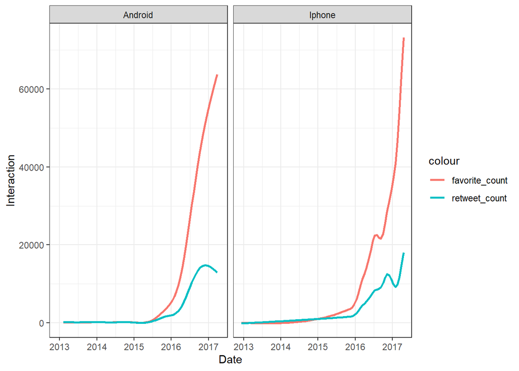

```r
trump_tweets %>%
  filter(source2=="Android" |
           source2=="Iphone") %>%
  ggplot(aes(x= date)) +
  geom_smooth(aes(y = favorite_count, colour = "favorite_count"), se= FALSE) +
  geom_smooth(aes(y = retweet_count, colour = "retweet_count"), se= FALSE) +
  facet_wrap(~source2)+
  ylab("Interaction")+
  xlab("Date")+
  theme_bw()
```

in terms of the interactions received by the tweets, the tweets written by the staff have more of them, both in terms of favourites and retweets. in particular, the number of retweets received by trump’s tweets starts to decrease around the second half of 2016, while for those written by his staff they start to increase around the same time. furthermore, for favourites, the slope seems to be greater for staff tweets

*TASK 3*

regression model:

the first objective for the exercise was to build the regression model between sentiments/emotion and retweets/favourites. to do this i decided to recode the two variables (negative and positive) to create a single one called “sentiments”. to do this i decided to make it positive - negative. the variable then has a scale from 10 to -6, where the two extremes are very positive(10) and very negative(-6)

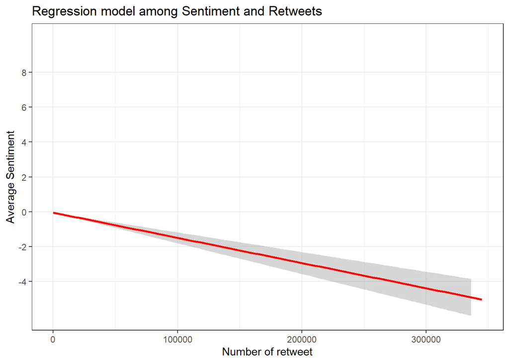

```r
ggplot(trump_tweets2, aes(x = retweet_count , y = sentiments)) +
  scale_y_binned() +
  geom_smooth(method = "lm", col = "red") +
  ylab("Average Sentiment") +
  xlab("Number of retweet") +
  ggtitle("Regression model among Sentiment and Retweets")+
  theme_bw()
```

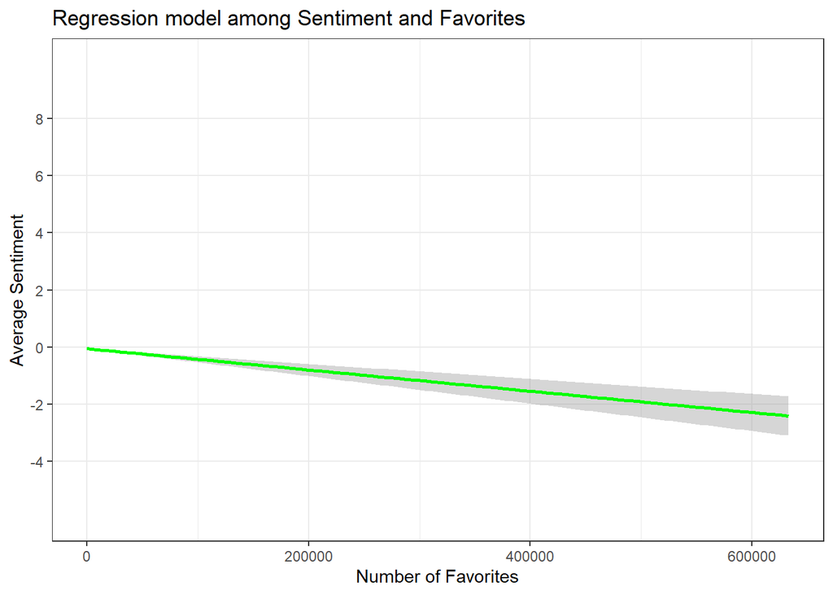

```r
ggplot(trump_tweets2, aes(x = favorite_count , y = sentiments)) +
  scale_y_binned() +
  geom_smooth(method = "lm", col = "green") +
  ylab("Average Sentiment") +
  xlab("Number of Favorites") +
  ggtitle("Regression model among Sentiment and Favorites")+
  theme_bw()
```

the two graphs above show the regression between the sentiments variable and the number of retweets and favourites. both models show a negative relationship, although for retweets the slope is greater. this means that sentiments tend to be more negative when the number of interactions to the tweet increases

grouping emotion:

```r
# create a variable for negative emotions with the function add_column and %>% operator
trump_tweets2 <- trump_tweets2 %>%
  add_column(
  neg_emotions= (trump_tweets2$sadness) +
    (trump_tweets2$anger) +
    (trump_tweets2$disgust) +
    (trump_tweets2$fear)
  )
# create a variable for positive emotions with the function add_column and %>% operator
trump_tweets2 <- trump_tweets2 %>%
  add_column(
    pos_emotions= (trump_tweets2$joy) +
      (trump_tweets2$anticipation) +
      (trump_tweets2$surprise) +
      (trump_tweets2$trust)
  )
# create a variable for emotions with the function add_column and %>% operator. i set up the function
# doing positive emotions - negative emotions
trump_tweets2 <- trump_tweets2 %>%
  add_column(
    emotions= (trump_tweets2$pos_emotions) - (trump_tweets2$neg_emotions)
)

##create a ratio for sentiments and emotions
# in order to weight the number of total words, i divided the function emotions and sentiments for the variable tot_words.

trump_tweets2 <- trump_tweets2 %>%
  add_column(
    sentimentsratio= (trump_tweets2$sentiments)/(trump_tweets2$tot_words))

trump_tweets2 <- trump_tweets2 %>%
  add_column(
    emotionsratio= ((trump_tweets2$pos_emotions)-(trump_tweets2$neg_emotions))/(trump_tweets2$tot_words)
)
```

with regard to the emotion variables (anger, anticipation, joy, disgust, sadness, fear, surprise and trust) I decided to recode them in a similar way to that used for sentiments: I divided them into two groups, one positive (anticipation, joy, trust and surprise) the other negative (disgust, fear, sadness, anger) and subtracted them. the emotion variable is a scale ranging from 21 (very positive emotions) to -14 (very negative emotions)

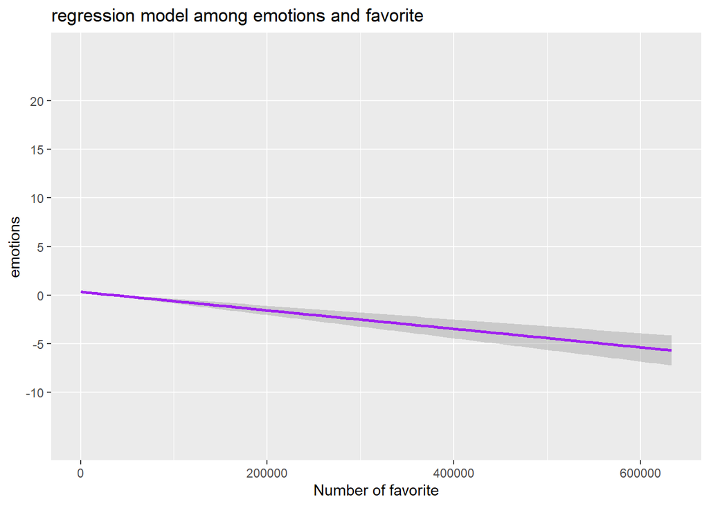

```r
ggplot(trump_tweets2, aes(x = favorite_count , y = emotions)) +
  geom_smooth(method = "lm", col = "purple") +
  scale_y_binned()+
  ylab("emotions") +
  xlab("Number of favorite") +
  ggtitle("regression model among emotions and favorite")+
  theme_gray()
```

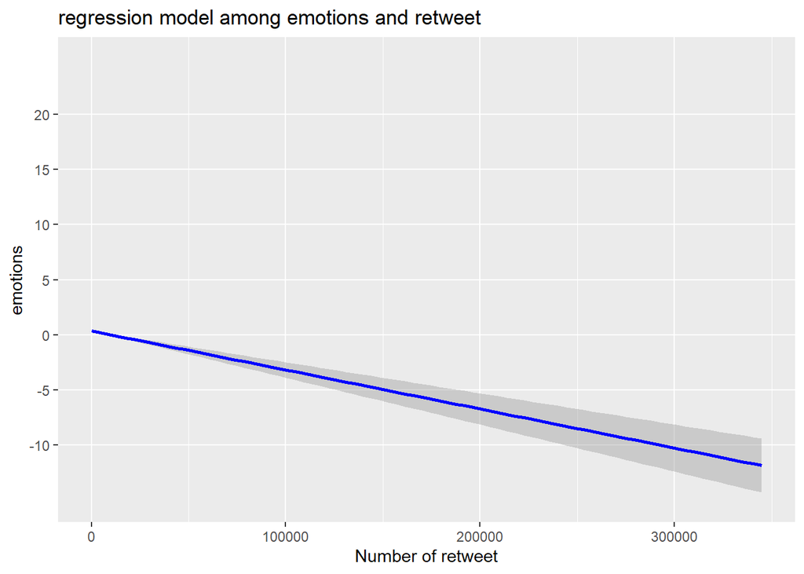

```r
ggplot(trump_tweets2, aes(x = retweet_count , y = emotions)) +
  geom_smooth(method = "lm", col = "blue") +
  scale_y_binned()+
  ylab("emotions") +
  xlab("Number of retweet") +
  ggtitle("regression model among emotions and retweet")+
  theme_gray()
```

for these two models relating to emotions, the relationship is also negative between the variables. as the emotions felt worsen, the number of retweets and favourites increases (the slope of the retweet curve is greater, as before).

*Regression model among emotions/sentiments and favorite/retweet, filtered by source of tweets*

before to continue with the regression between emotion/sentiment and favourite/retweet filtered for the source of the tweets, i decided to ‘weight’ the variables by dividing emotion and sentiment by the variable tot_words. in this way i created the variables ‘emotions ratio’ and ‘sentiments ratio’.

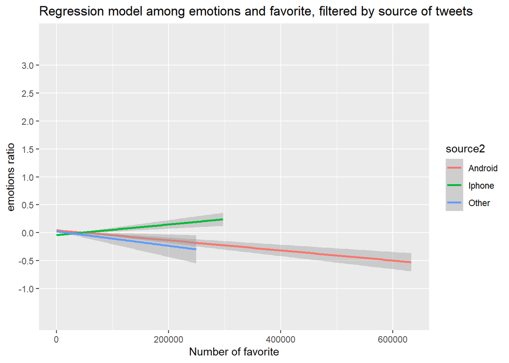

```r
ggplot(trump_tweets2, aes(x = favorite_count , y = emotionsratio, group=source2)) +
  geom_smooth(method = "lm", aes(col = source2)) +
  scale_y_binned()+
  ylab("emotions ratio") +
  xlab("Number of favorite") +
  ggtitle("Regression model among emotions and favorite, filtered by source of tweets")+
  theme_gray()
```

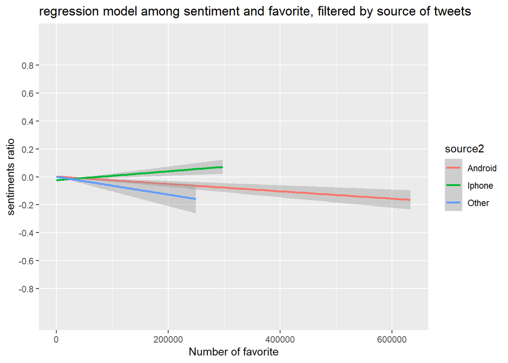

```r
ggplot(trump_tweets2, aes(x = favorite_count , y = sentimentsratio, group=source2)) +
  geom_smooth(method = "lm", aes(col = source2)) +
  scale_y_binned()+
  ylab("sentiments ratio") +
  xlab("Number of favorite") +
  ggtitle("regression model among sentiment and favorite, filtered by source of tweets")+
  theme_gray()
```

the first two plots here above to be analyzed are those for the favourite_count variable. these two plots are very similar: the regression for android and other sources are negative, while for iphone’s is positive. furthermore, we can say that weighting by tot_words the curves are more “flat”.

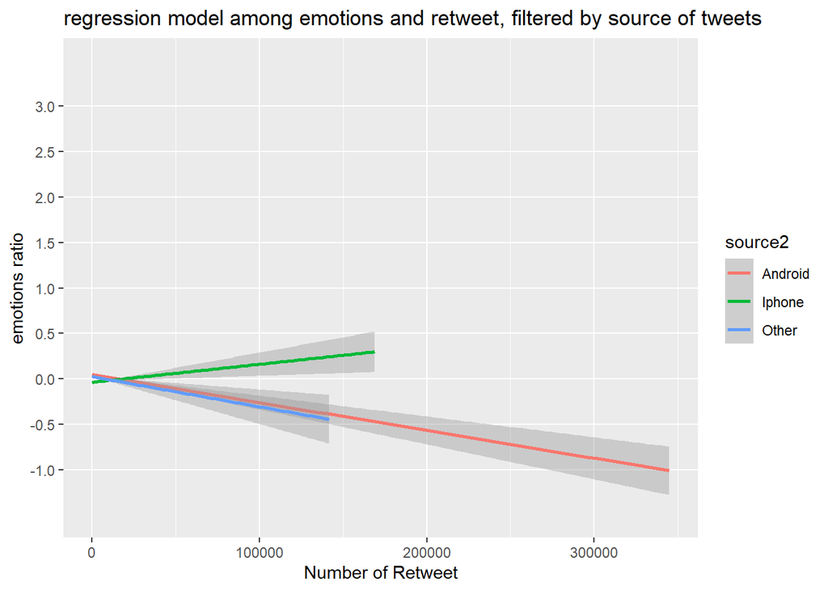

```r
ggplot(trump_tweets2, aes(x = retweet_count , y = emotionsratio, group=source2)) +
  geom_smooth(method = "lm", aes(col = source2)) +
  scale_y_binned()+
  ylab("emotions ratio") +
  xlab("Number of Retweet") +
  ggtitle("regression model among emotions and retweet, filtered by source of tweets")+
  theme_gray()
```

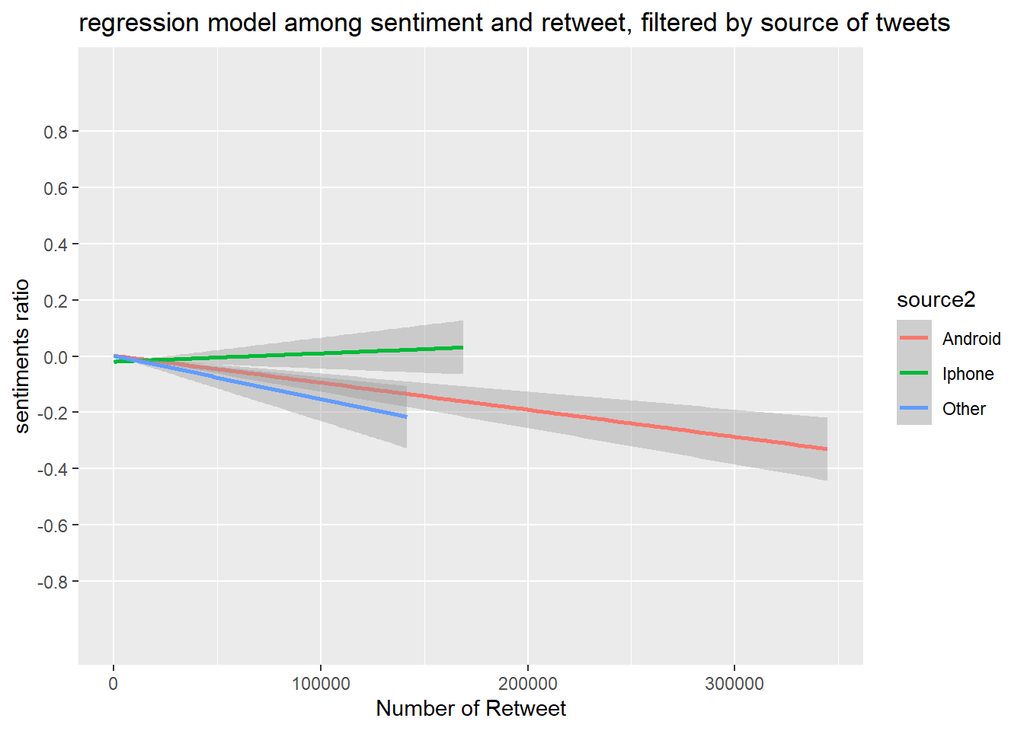

```r
ggplot(trump_tweets2, aes(x = retweet_count , y = sentimentsratio, group=source2)) +
  geom_smooth(method = "lm", aes(col = source2)) +
  scale_y_binned()+
  ylab("sentiments ratio") +
  xlab("Number of Retweet") +
  ggtitle("regression model among sentiment and retweet, filtered by source of tweets")+
  theme_gray()
```

The second two graphs here above to analyze are those for the retweet_count variable. These two graphs are very similar to the previous graphs: the regression for android and other sources is negative, while the regression for iphone is positive. trump’s staff therefore probably writes more accurate tweets than trump’s because it is the only positive relationship (as the emotions/sentiments variable increases, the number of retweets also increases). in addition, the relationship with retweets is stronger since the slope of the curve is greater.

*TASK 4*

Step 4 of the exercise finally asks you to analyse the number of tweets written from trump’s profile. this involves analysing 4 main dates:

- June 16, 2015 (Trump campaign was officially launched) blue line
- May 4, 2016 (Trump became the presumptive nominee for the Republicans) green line
- July 19, 2016 (Trump became the the official nominee) yellow line
- November 8, 2016 (The presidential elections happened) red line

In order to evidence in the graphs those dates, i decide to use the function *geom_vline*, setting the first tweet number of the day. In order to have a clearer view of these periods, I decided to set up the graphs starting on 01-01-2015.

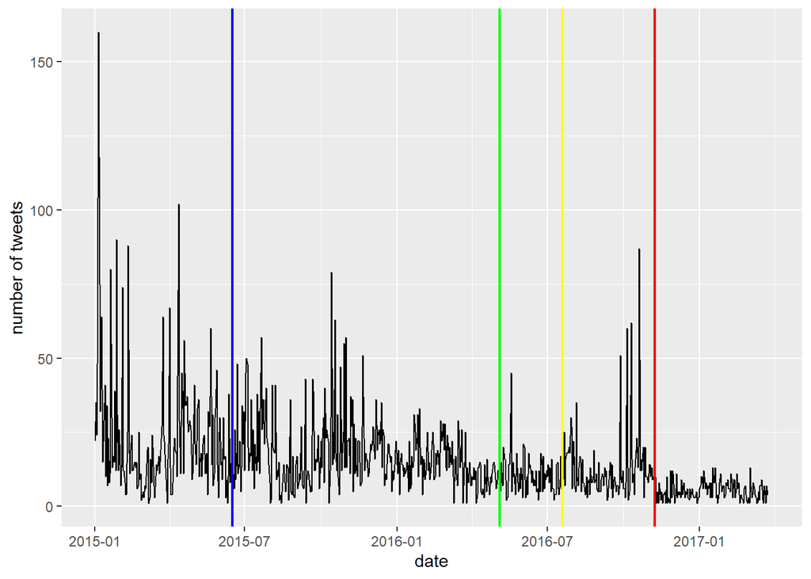

```r
# using as.numeric function to set the position of the first tweet for a selected day
ggplot(trump_tweets2, aes(x=date)) +
  geom_freqpoly(stat = "count")+
  geom_vline(xintercept=as.numeric(trump_tweets2$date[22157]),lwd=0.75,colour="blue")+
  geom_vline(xintercept=as.numeric(trump_tweets2$date[27712]),lwd=0.75,colour="green")+
  geom_vline(xintercept=as.numeric(trump_tweets2$date[28492]),lwd=0.75,colour="yellow")+
  geom_vline(xintercept=as.numeric(trump_tweets2$date[29945]),lwd=0.75,colour="red")+
  scale_x_date(limits = as.Date(c("2015-01-01","2017-03-25")))+   #to focus only from 2015 to 2017
  labs(y= "number of tweets", x = "date")
```

the first graph here above relates the number of tweets for each day. as we can clearly see the largest number of tweets is written in the first period before his official candidacy, reaching a peak of about 150 tweets in early 2015. in the second period between the blue and green lines (campaign and presumptive nominee for the Republicans) the number of tweets seems fairly constant, except for a short period towards the end of 2015, when there is a peak of about 80 tweets per day. the same situation between the green and yellow lines (Trump became the official nominee for Republican party). in that period there is a lower peak of almost 50 tweets per day. the most interesting period seems to me to be the period before the elections: in this period of time we can see how the number of tweets increases progressively, reaching almost 100tweets/day. it would be interesting to see the source of the tweets, because most probably these tweets were written by political professionals, thus by trump’s staff. finally, the last period (after the presidential election in which trump won) we can see that the total number of tweets is very low and constant.

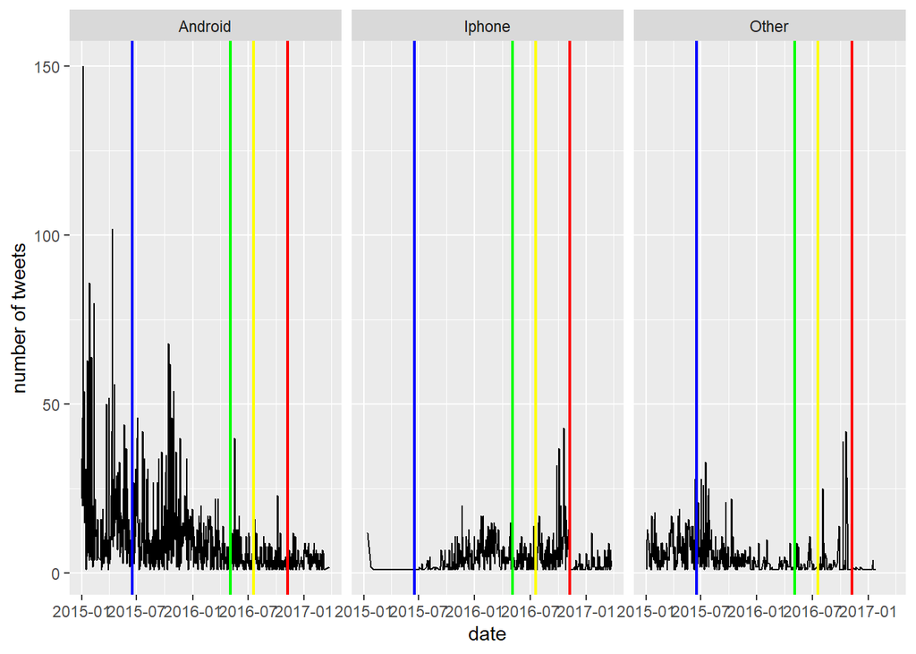

```r
ggplot(trump_tweets2, aes(x=date)) +
  geom_freqpoly(stat = "count")+
  facet_wrap(~source2) +
  geom_vline(xintercept=as.numeric(trump_tweets2$date[22157]),lwd=0.75,colour="blue")+
  geom_vline(xintercept=as.numeric(trump_tweets2$date[27712]),lwd=0.75,colour="green")+
  geom_vline(xintercept=as.numeric(trump_tweets2$date[28492]),lwd=0.75,colour="yellow")+
  geom_vline(xintercept=as.numeric(trump_tweets2$date[29945]),lwd=0.75,colour="red")+
  scale_x_date(limits = as.Date(c("2015-01-01","2017-03-25")))+
  labs(y= "number of tweets", x = "date")
```

these three graphs are in my opinion very interesting, because they highlight the source of the tweets. the first refers to the tweets written from android(trump), the second those written from iphone(trump’s staff) the third other sources. as i said before you can see that the total number of tweets written by trump decreases progressively during these periods, while the tweets written by his staff increase. at this time it is possible that the tweets that were written from his profile were more accurate and targeted to take consensus from voters

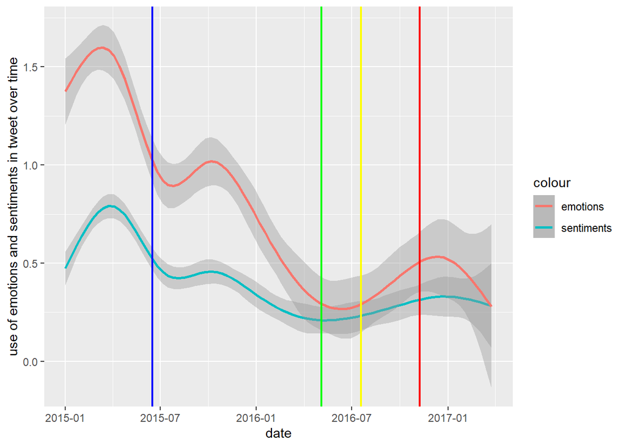

```r
ggplot(trump_tweets2, aes(x=date)) +
  geom_smooth(aes(y = sentiments, col="sentiments"))+
  geom_smooth(aes(y = emotions, col="emotions"))+
  geom_vline(xintercept=as.numeric(trump_tweets2$date[22157]),lwd=0.75,colour="blue")+
  geom_vline(xintercept=as.numeric(trump_tweets2$date[27712]),lwd=0.75,colour="green")+
  geom_vline(xintercept=as.numeric(trump_tweets2$date[28492]),lwd=0.75,colour="yellow")+
  geom_vline(xintercept=as.numeric(trump_tweets2$date[29945]),lwd=0.75,colour="red")+
  scale_x_date(limits = as.Date(c("2015-01-01","2017-03-25")))+
  labs(y= "use of emotions and sentiments in tweet over time", x = "date")
```

the last graph, on the other hand, shows the emotions and sentiment used by the tweets. the two lines have similar trends: both the emotions used and the sentiment have been getting worse and worse, except in the period right before the election, where the curves have a brief rise( we saw earlier that in this period many of the tweets were written by trump’s staff)

*EXERCISE 2- SPOTIFY*

```r
#open packages and import dataset
library(rio)
setwd("/Users/trava/Downloads/")
spotify <- import("spotify.rds")

library(tidyverse)
library(dplyr)
options(scipen = 999)
```

in this latest exercise regarding the spotify dataset, I decided to consider these three artists:

- U2
- Good Charlotte
- PRhyme

I then created a dataset with these three artists by averaging the features for each, using the summarise_at function. this dataframe is called *mean_my* the purpose is to see the averages of each feature by comparing them to all the others within the dataset. i also created another dataframe with the mean of features for all the observations, that i called *mean_spotify* the last step in creating the dataset was to merge the two datasets using the rbind function. the dataframe used will be this merged one, which i called *totalmean*: the observations are: u2, good charlotte, prhyme and total.

```r
#creating a dataset called df with only the observation for u2, good charlotte and prhyme

df <- spotify %>%
  filter(artist_name == "U2"|
           artist_name =="Good Charlotte"|
           artist_name =="PRhyme")

# calculating mean for features i select with the function summarise_at
mean_my <- df %>%
  group_by(artist_name) %>%
  summarise_at(vars("acousticness","danceability", "duration_ms", "energy", "instrumentalness",
                    "key", "liveness", "loudness", "mode", "speechiness", "tempo",
                    "time_signature",  "valence", "popularity"),mean)
#calculating the mean for features i select from the principal dataset. i didnt set the function group_by, in order to
#calculate the sample mean
mean_spotify <- spotify %>%
  summarise_at(vars("acousticness","danceability", "duration_ms", "energy", "instrumentalness",
                    "key", "liveness", "loudness", "mode", "speechiness", "tempo",
                    "time_signature",  "valence", "popularity"),mean)
#creating a dataframe with the sample mean, adding also a new column with artist name=total.
#i need to do that because its crucial for merging the two dataframe(number of columns must be the same)
mean_spotify <- mean_spotify %>%
  add_column(artist_name = "total")
#merging the two dataframe
totalmean <- rbind(mean_my, mean_spotify)
```

```r
table(totalmean$artist_name)
```

```
##
## Good Charlotte         PRhyme          total             U2
##              1              1              1              1
```

*1- Acousticness*

This value describes how acoustic a song is. A score of 1.0 means the song is most likely to be an acoustic one.

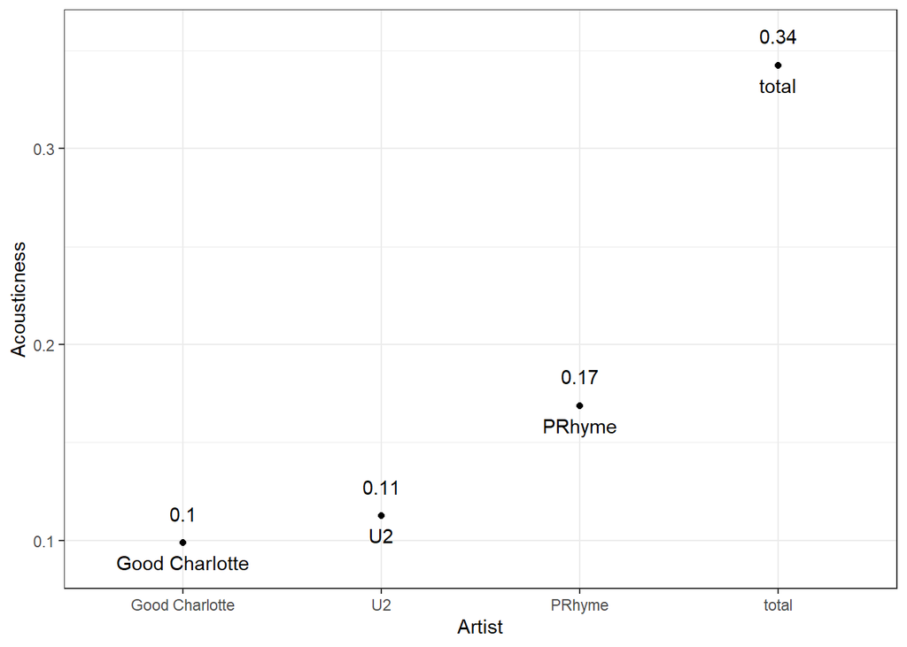

```r
ggplot(data= totalmean, aes(y = acousticness, x = reorder(artist_name, acousticness, function(x) mean(x, na.rm = T)),)) +
  geom_point() +
  geom_text(aes(label = artist_name), nudge_y = -0.01)+
  geom_text(aes(label = round(acousticness,digits = 2)), nudge_y = 0.015)+
  xlab("Artist") +
  ylab("Acousticness") +
  theme_bw()
```

this graph show that i probably prefer music with less instruments. the difference between total and, for example, Good charlotte is very noticeable.

*2- Danceability*

“Danceability describes how suitable a track is for dancing based on a combination of musical elements including tempo, rhythm stability, beat strength, and overall regularity. A value of 0.0 is least danceable and 1.0 is most danceable”.

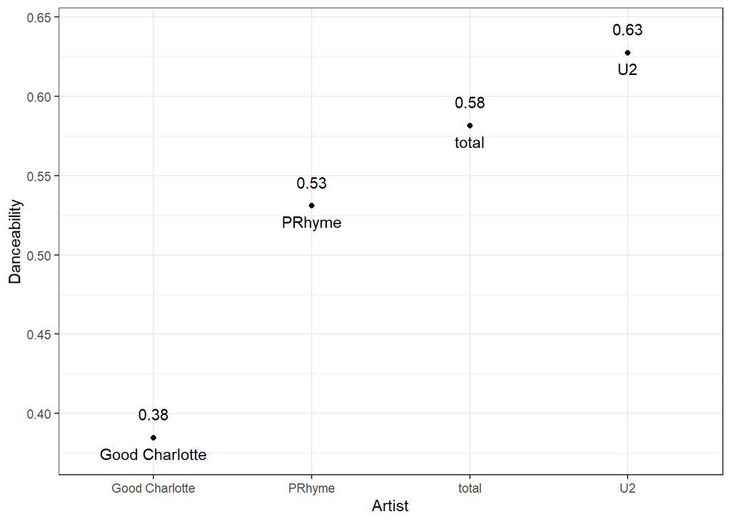

```r
ggplot(data= totalmean, aes(y = danceability, x = reorder(artist_name, danceability, function(x) mean(x, na.rm = T)),)) +
  geom_point() +
  geom_text(aes(label = artist_name), nudge_y = -0.01)+
  geom_text(aes(label = round(danceability,digits = 2)), nudge_y = 0.015)+
  xlab("Artist") +
  ylab("Danceability") +
  theme_bw()
```

i have to be honest, i don’t get excited about the idea of dancing in general. i prefer going to a concert for example than going to a disco. so i’m not really surprised that i prefer music that is not very danceable. i’m surprised about u2’s result, however they actually make very rhythmic music

*3- Energy*

“Represents a perceptual measure of intensity and activity. Typically, energetic tracks feel fast, loud, and noisy”.

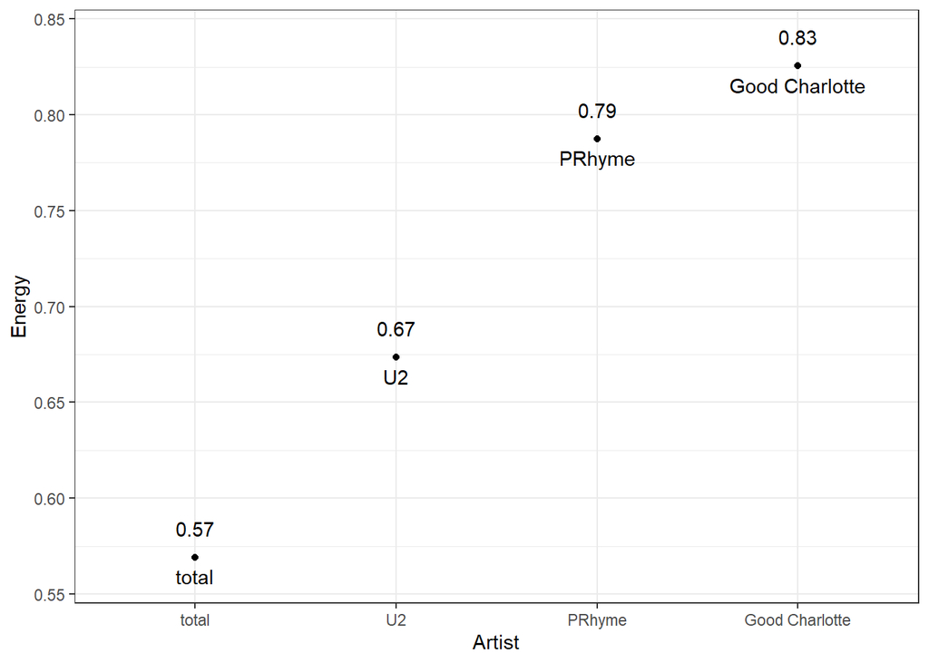

```r
ggplot(data= totalmean, aes(y = energy, x = reorder(artist_name, energy, function(x) mean(x, na.rm = T)),)) +
  geom_point() +
  geom_text(aes(label = artist_name), nudge_y = -0.01)+
  geom_text(aes(label = round(energy,digits = 2)), nudge_y = 0.015)+
  xlab("Artist") +
  ylab("Energy") +
  theme_bw()
```

i really like energetic music, so the results of this graph reflect my expectations. i listen to these kinds of songs before playing football. the results show that i listen to more energetic music than the sample average

*4- Instrumentalness*

This value represents the amount of vocals in the song. The closer it is to 1.0, the more instrumental the song is.

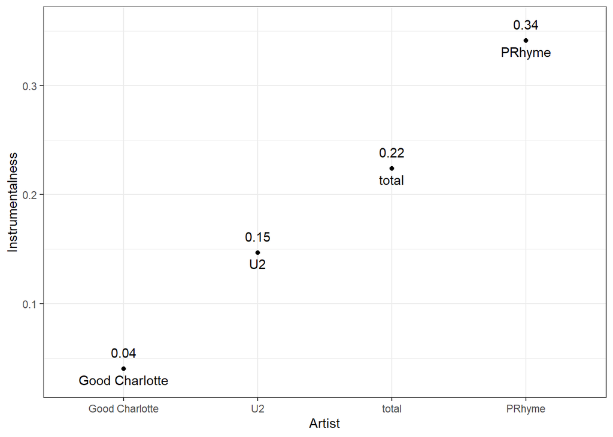

```r
ggplot(data= totalmean, aes(y = instrumentalness, x = reorder(artist_name, instrumentalness, function(x) mean(x, na.rm = T)),)) +
  geom_point() +
  geom_text(aes(label = artist_name), nudge_y = -0.01)+
  geom_text(aes(label = round(instrumentalness,digits = 2)), nudge_y = 0.015)+
  xlab("Artist") +
  ylab("Instrumentalness") +
  theme_bw()
```

this graph shows how much songs are sung or played. only prhyme is above average, while the other two bands generally make highly sung songs. (ex. good charlotte have an average of only 0.04 in this category)

*5- Liveness*

This value describes the probability that the song was recorded with a live audience. According to the official documentation “a value above 0.8 provides strong likelihood that the track is live”

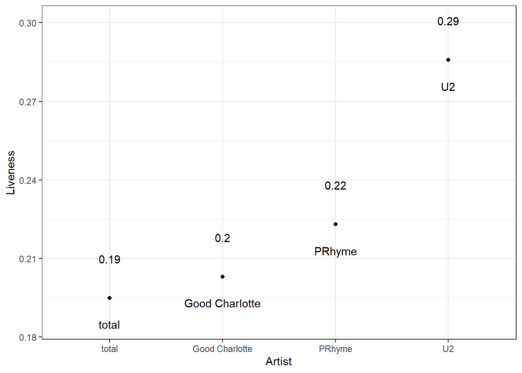

```r
ggplot(data= totalmean, aes(y = liveness, x = reorder(artist_name, liveness, function(x) mean(x, na.rm = T)),)) +
  geom_point() +
  geom_text(aes(label = artist_name), nudge_y = -0.01)+
  geom_text(aes(label = round(liveness,digits = 2)), nudge_y = 0.015)+
  xlab("Artist") +
  ylab("Liveness") +
  theme_bw()
```

this graph shows the probability that the song is recorded live. although there is little chance that on spotify the songs are live ( or the sounds are those similar to a concert) the graph shows that the artists I chose have very similar sounds to live concerts, compared to the sample average.

*6- Speechiness*

“Speechiness detects the presence of spoken words in a track”. If the speechiness of a song is above 0.66, it is probably made of spoken words, a score between 0.33 and 0.66 is a song that may contain both music and words, and a score below 0.33 means the song does not have any speech.

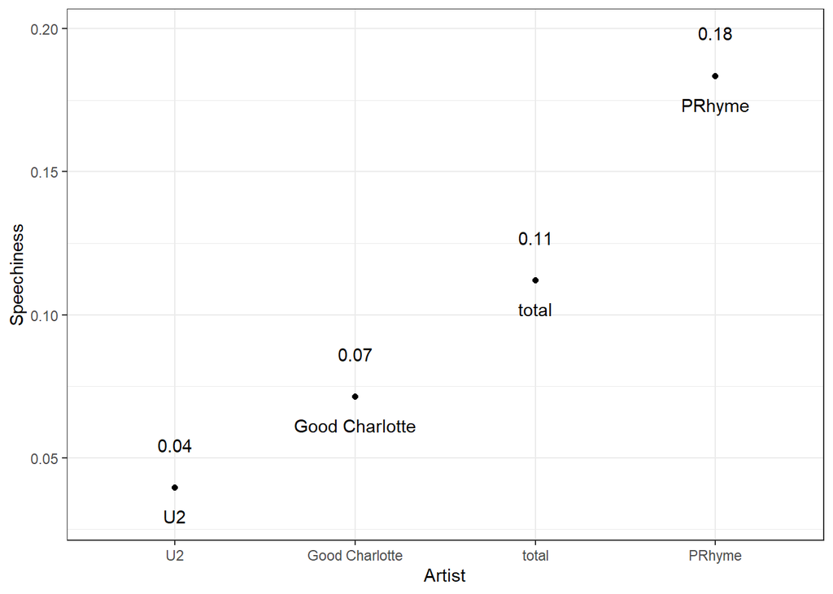

```r
ggplot(data= totalmean, aes(y = speechiness, x = reorder(artist_name, speechiness, function(x) mean(x, na.rm = T)),)) +
  geom_point() +
  geom_text(aes(label = artist_name), nudge_y = -0.01)+
  geom_text(aes(label = round(speechiness,digits = 2)), nudge_y = 0.015)+
  xlab("Artist") +
  ylab("Speechiness") +
  theme_bw()
```

although I haven’t found many rap artists that I usually listen to, I must premise that it is my favorite music genre. generally rap songs are very talky, which fully reflects this feature. PRhyme (rap) has the highest value in this category. however, the other two music groups are below the sample average.

*7- Valence*

“A measure from 0.0 to 1.0 describing the musical positiveness conveyed by a track. Tracks with high valence sound more positive (e.g. happy, cheerful, euphoric), while tracks with low valence sound more negative (e.g. sad, depressed, angry)”.

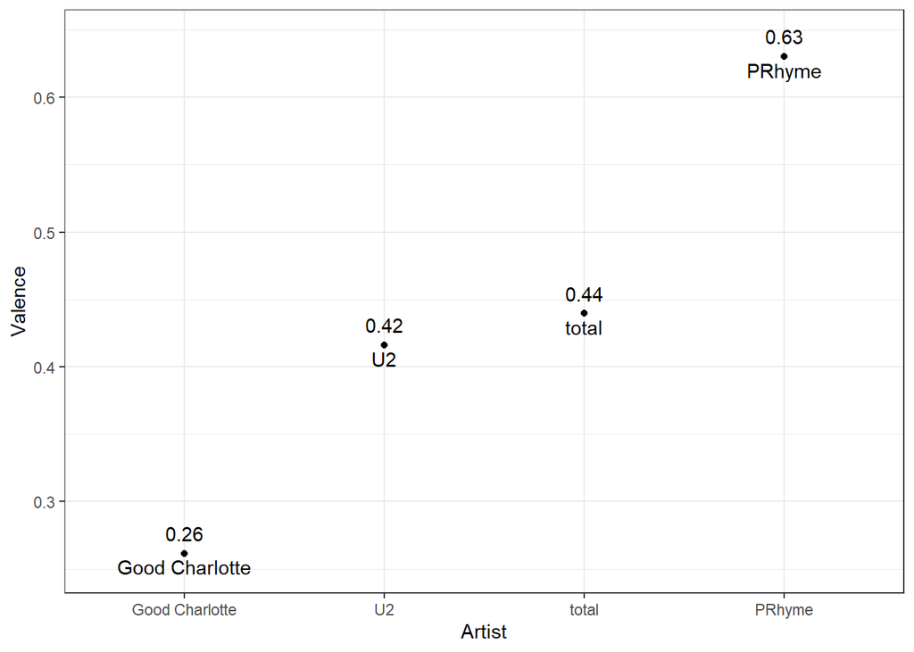

```r
ggplot(data= totalmean, aes(y = valence, x = reorder(artist_name, valence, function(x) mean(x, na.rm = T)),)) +
  geom_point() +
  geom_text(aes(label = artist_name), nudge_y = -0.01)+
  geom_text(aes(label = round(valence,digits = 2)), nudge_y = 0.015)+
  xlab("Artist") +
  ylab("Valence") +
  theme_bw()
```

the graph shows the types of emotions that the artist expresses (positive - negative). prhyme has very positive valences compared to the sample mean, while u2 and good charlotte are more negative.

*8- Popularity*

[figure not shown]

```r
ggplot(data= totalmean, aes(y = popularity, x = reorder(artist_name, popularity, function(x) mean(x, na.rm = T)),)) +
  geom_point() +
  geom_text(aes(label = artist_name), nudge_y = -0.01)+
  geom_text(aes(label = round(popularity,digits = 2)), nudge_y = 0.015)+
  xlab("Artist") +
  ylab("Popularity") +
  theme_bw()
```

the last graph concerns the average popularity of the artists’ songs. the scale goes from 0 to 100, where 100 is the maximum popularity value. as shown, two of my top three artists are above the sample mean, while only prhyme is below this value.